# Antimicrobial Use Survey - New Figures

## Demographics

Q2 - Year of Graduation from a College of Veterinary Medicine Q3 License to Practice Q4 Current Food Animal Practice Situation Q5 Organization Membership Q6 Food Animal Species Serving Practice

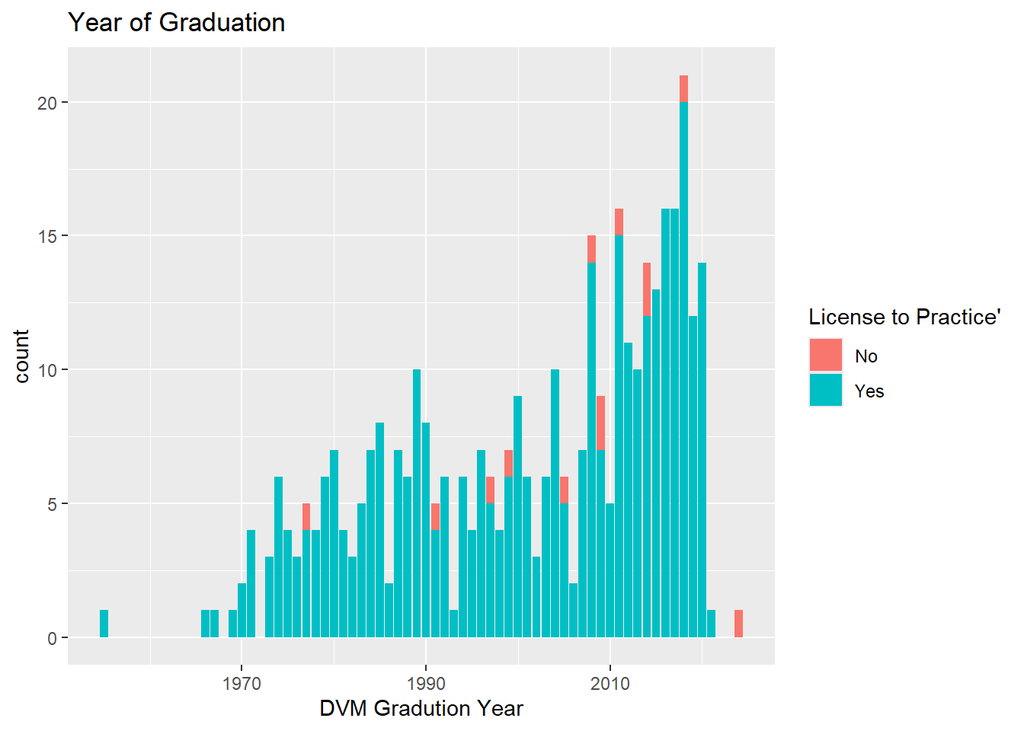

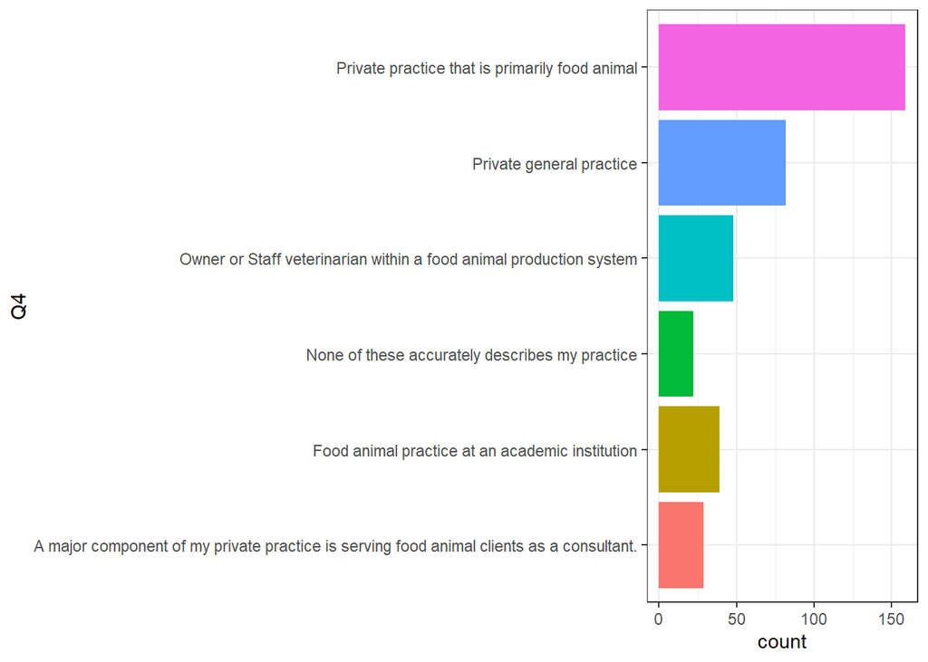

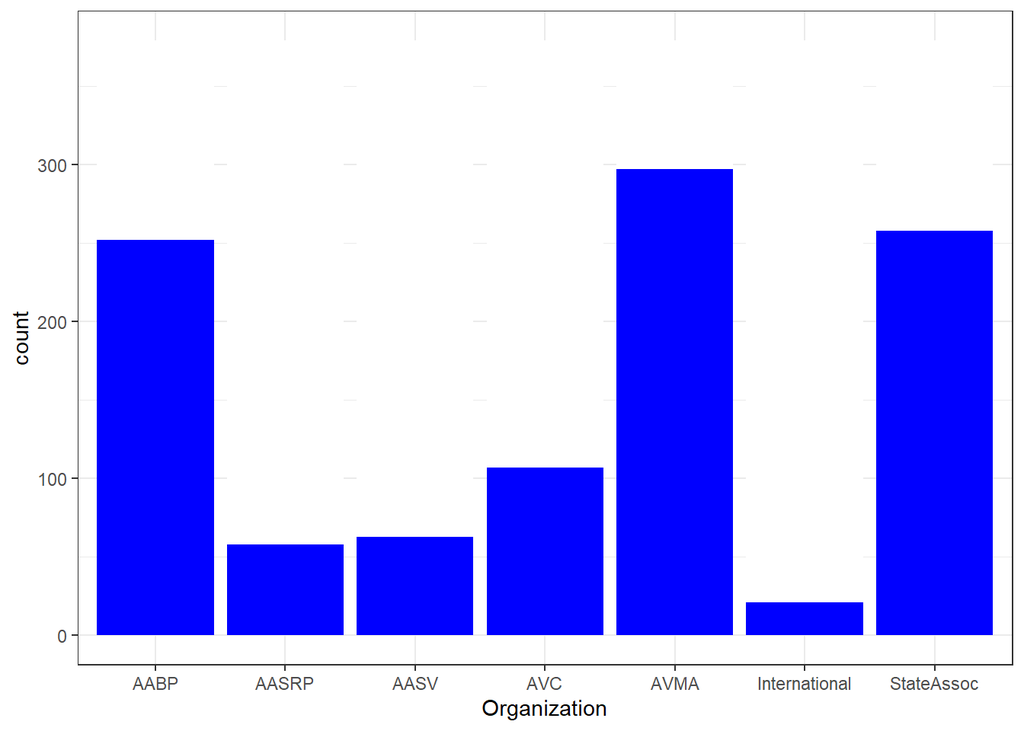

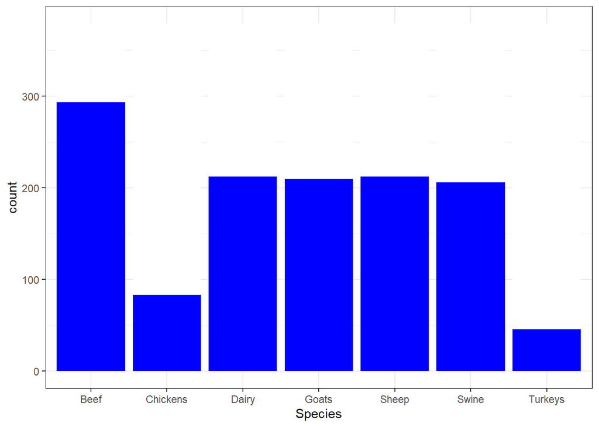

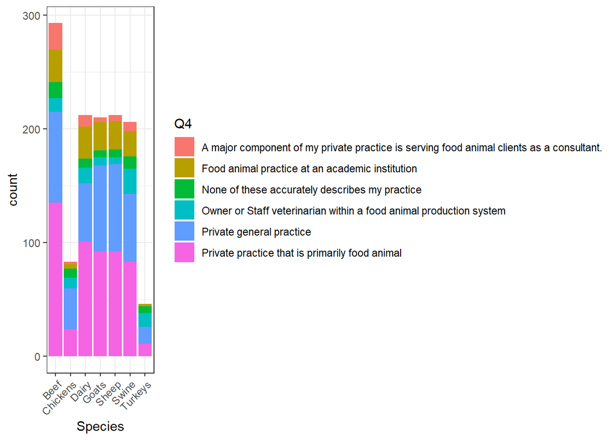

## Question 7 - what matters

Inputs that Contribute to Decisions in Selecting a Food Animal Antimicrobial Regimen

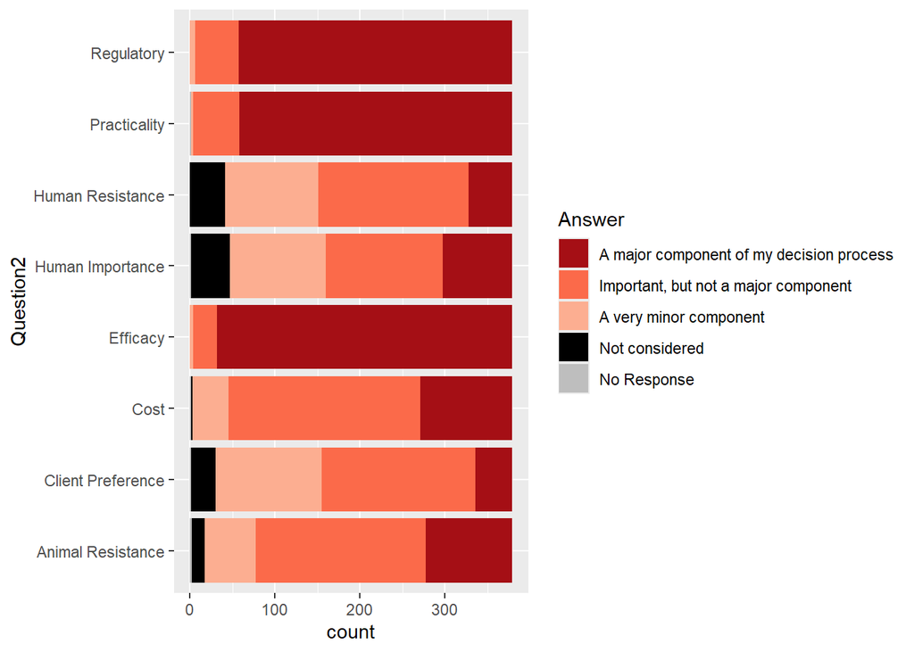

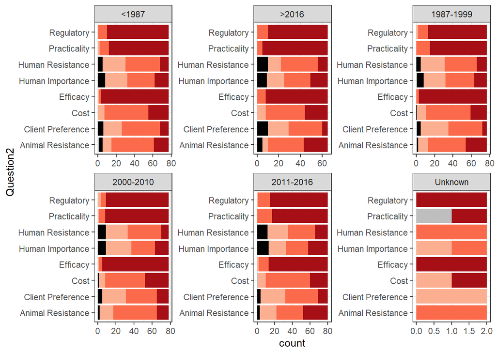

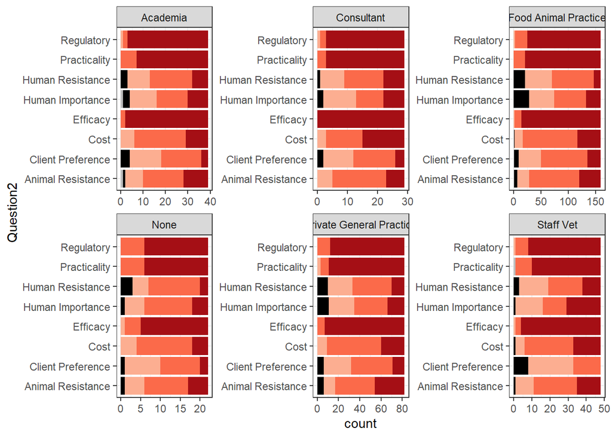

## Question 8

What did we miss?

[output not shown]

[output cut: 152 more lines]

## Question 9

Q9 Extent of Antimicrobial Susceptibility Testing BEFORE Antibiotic Treatment Q10 Extent of Antimicrobial Susceptibility Testing AFTER ENCOUNTERING A PERCEIVED LACK OF TREATMENT EFFICACY Q11 Extent of Antimicrobial Susceptibility Testing to Routinely Monitor Antimicrobial Susceptibility of Pathogens Which Cause Disease in Your Client’s Herd or Flocks ## Q12 Extent of Antimicrobial Susceptibility Testing to Routinely Monitor Antimnicrobial Susceptibility of Potential Foodborne Pathogens in Your Client’s Herd or Flocks

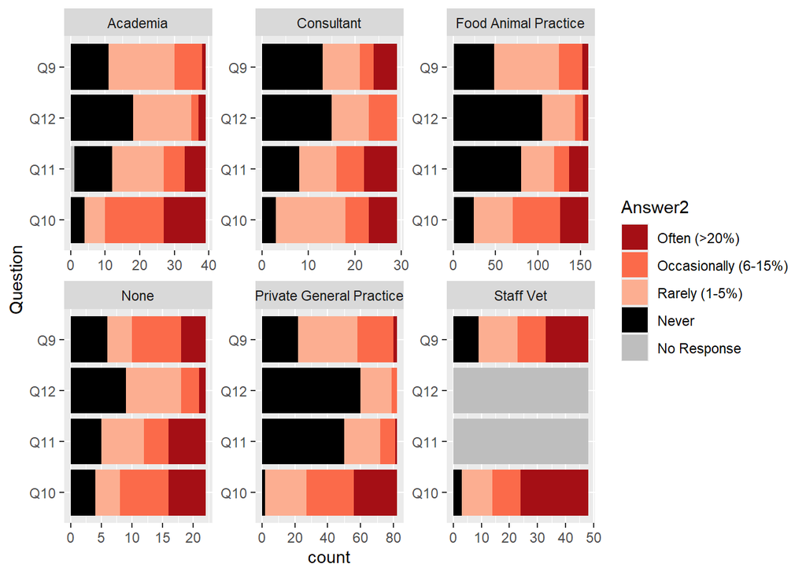

## Question 13, 14

Q13 Monitor Antimicrobial Susceptibility of Pathogens Which Cause Disease (Y/N) (Staff Vets Only) Q14 Monitor Antimicrobial Susceptibility of Zoonotic Pathogens (Y/N) (Staff Vets Only)

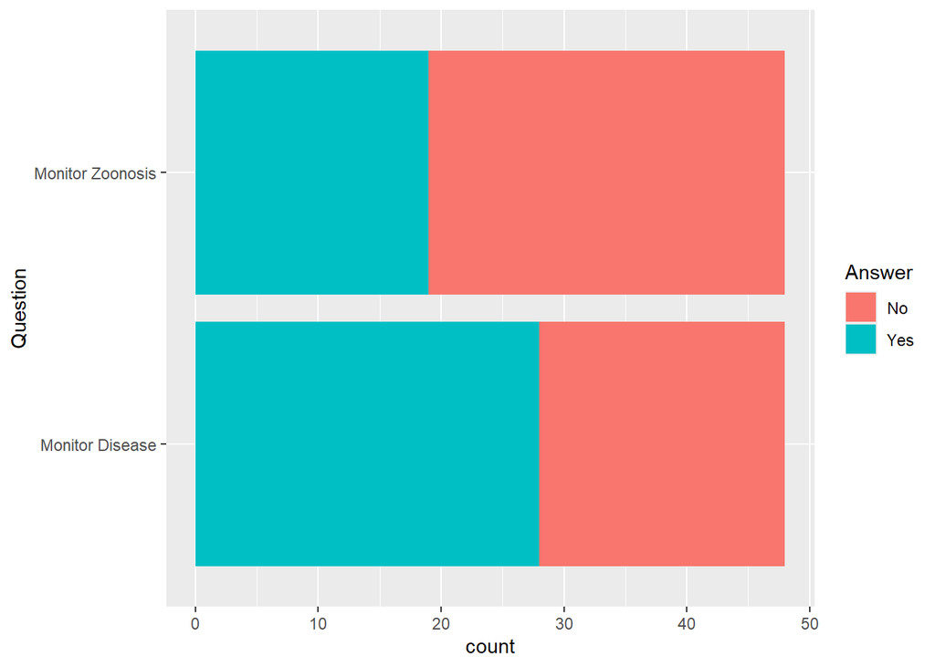

## Question 15

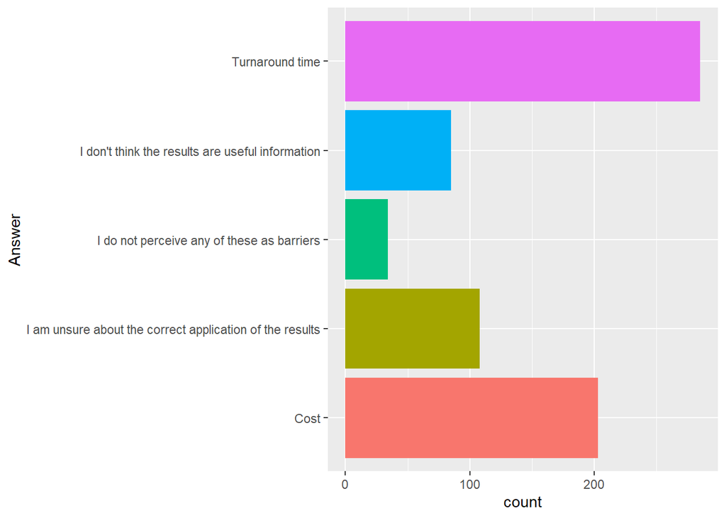

## Question 16

Free text response . . .

## Question 17

Level of Confidence in Knowledge Related to Antimicrobial Use Areas

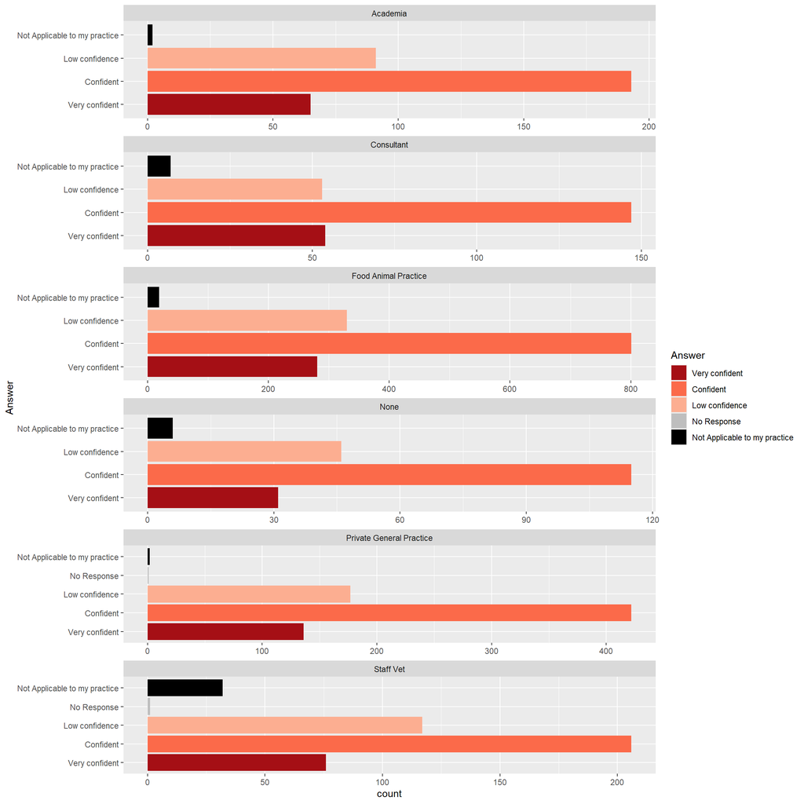

## Question 18

Interest in Certificate Program

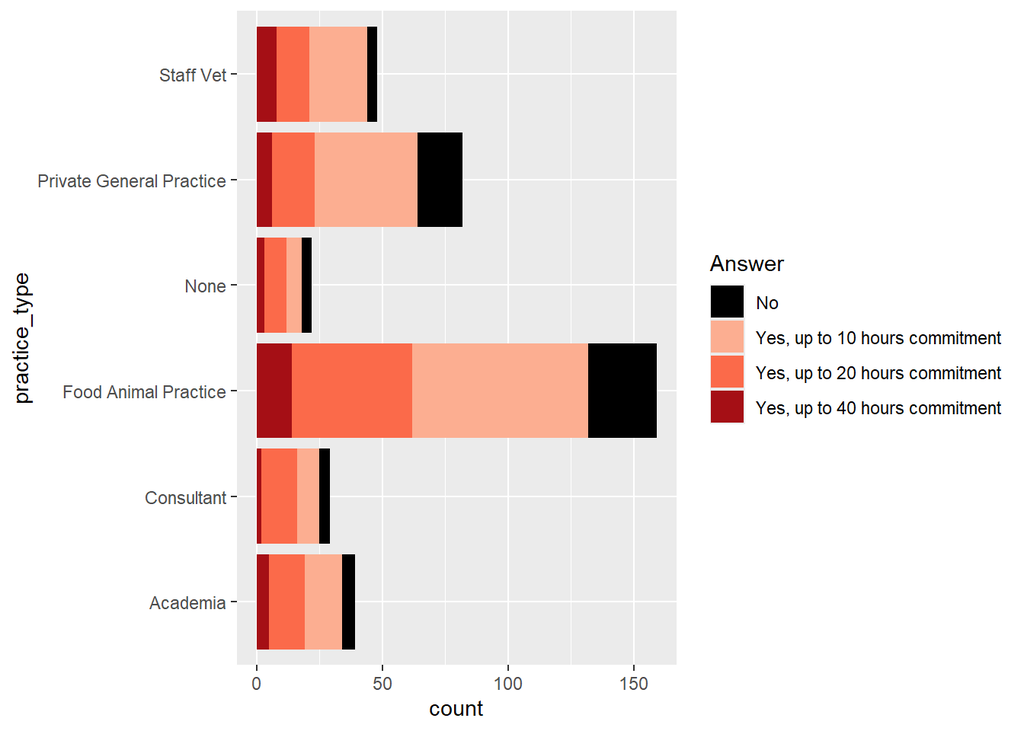

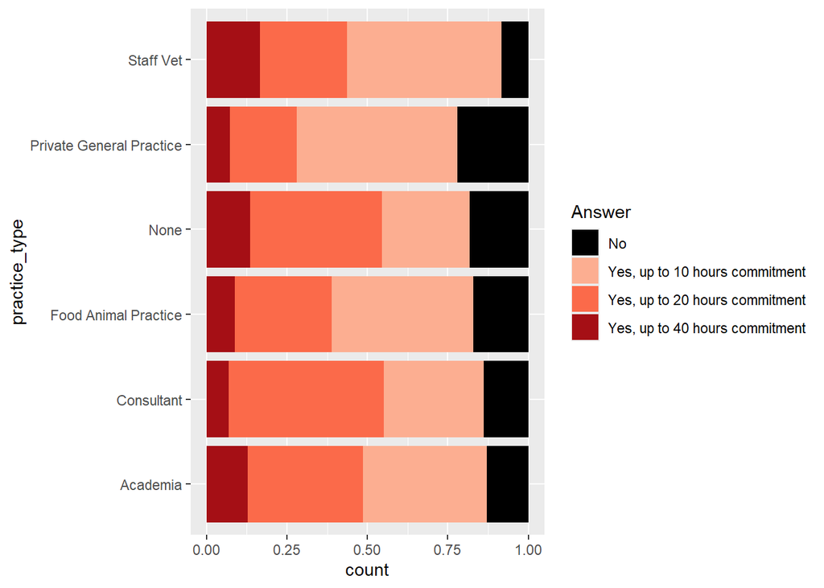

## Question 19, 20

Concern About AMR as Problem for Antimicrobial Efficacy in Treatment, Prevention, and Control of Livestock Diseases

Concern About AMR in Livestock to Treat Bacterial Infections in Humans

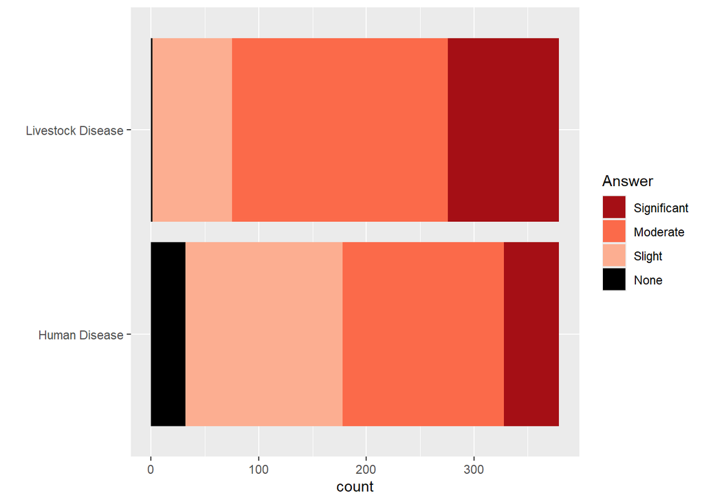

[output not shown]

## Question 21 to 23

Client with good working relation requests antimicrobial for prevention and control of disease. How willing are you to take the risk of not authorizing continued use?

Client with good working relation requests antimicrobial for prevention and control of disease. Risk percieved to relationship if signifcant spike in morbidity or mortality.

New client requests antimicrobial for prevention and control of disease. Risk percieved to relationship if significant spike in morbidity or mortality.

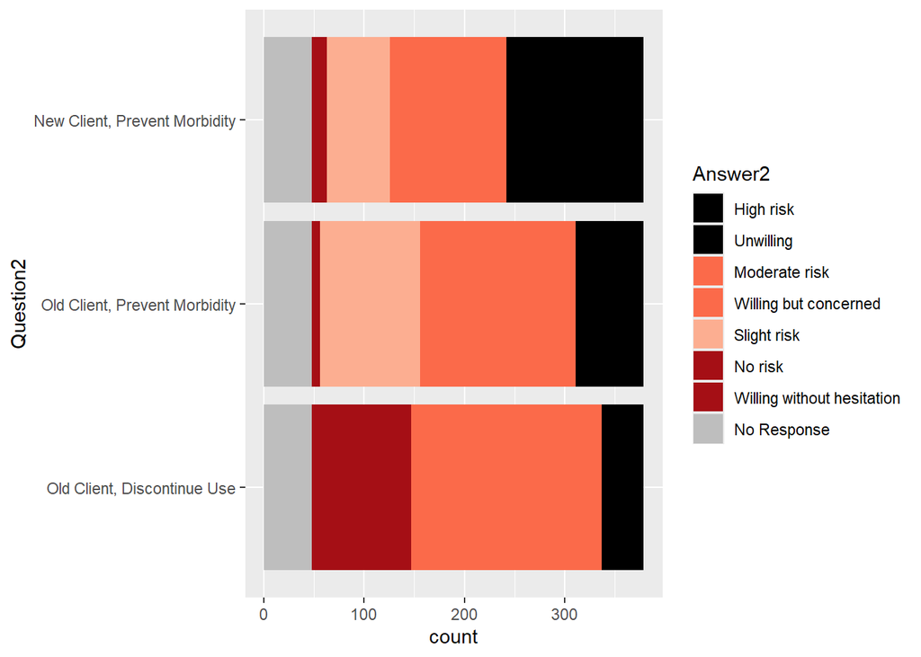

## Question 24, 25

Q24 For what proportion of your food animal clients do you periodically review data which includes:

Q25 For which of the following categories do you routinely review data from the flocks or herds under your care?

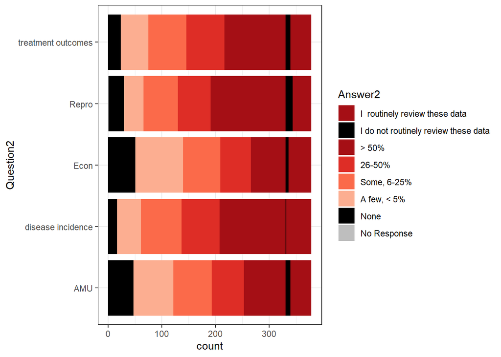

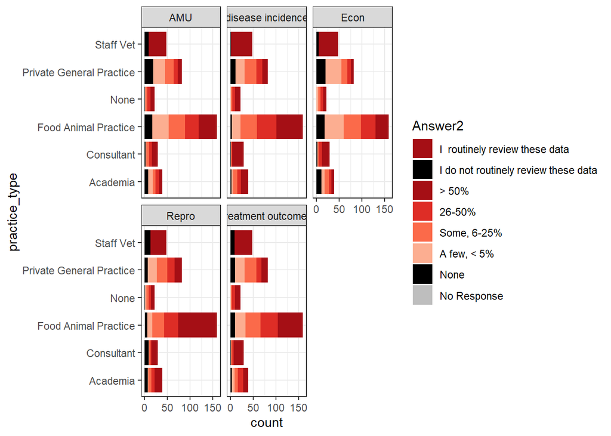

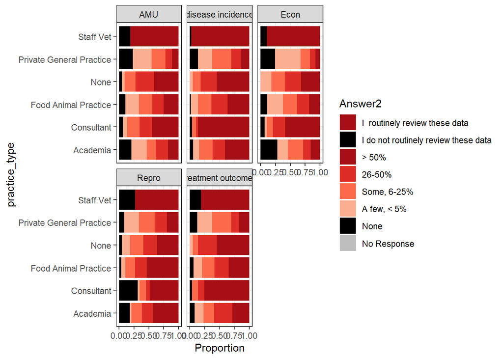

## Question 26

Q26 Given that adequate data tools were available and you were appropriately compensated, would you be willing to begin or expand routine analysis of disease incidence, antimicrobial use, and treatment outcome data with your clients? (Y/N)

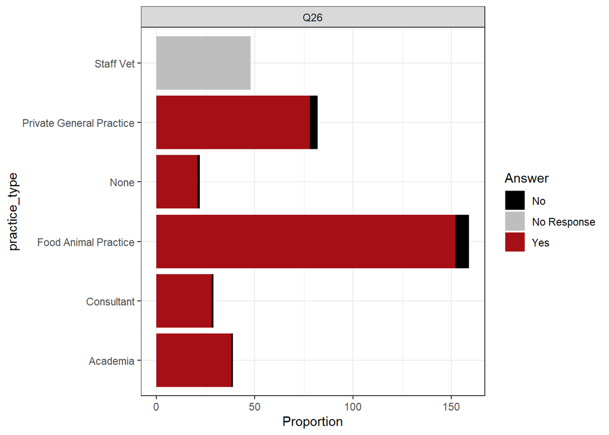

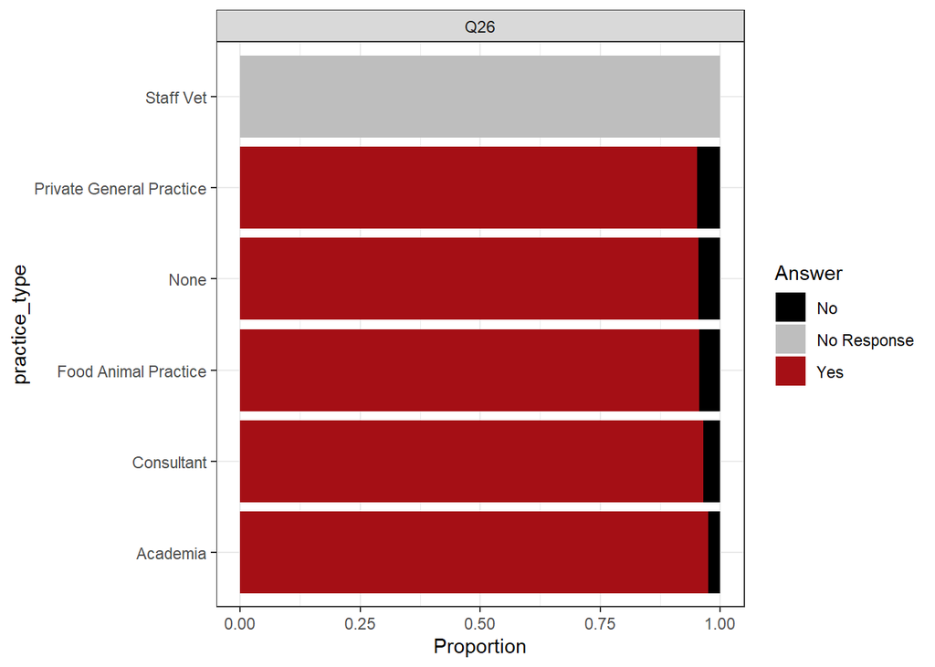

## Question 27

Q27 Considering the clients for which you do not review data related to disease incidence, antimicrobial use, or treatment outcome, which of these barriers do you perceive as contributing to this lack of interaction for at least some clients?

Q28 If you do not review data related to disease incidence, antimicrobial use, or treatment outcome within the herds or flocks under your care, which of these barriers do you perceive as contributing to this lack of review?

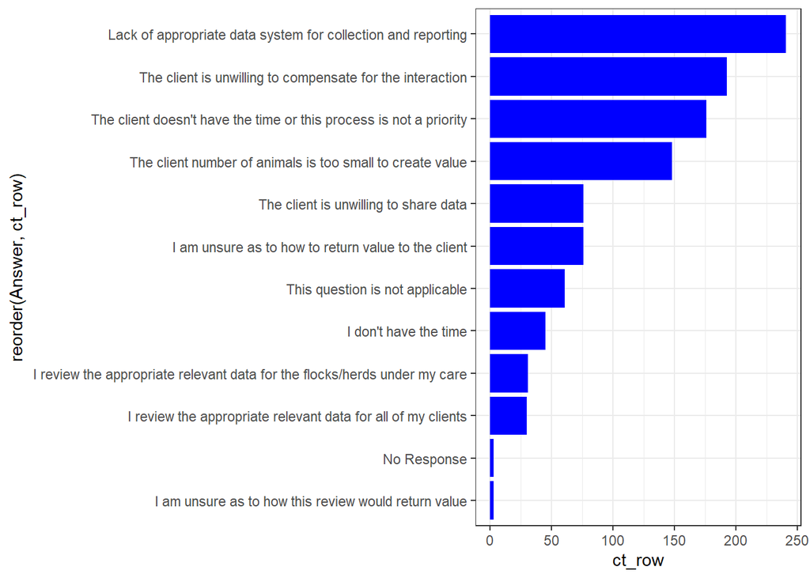

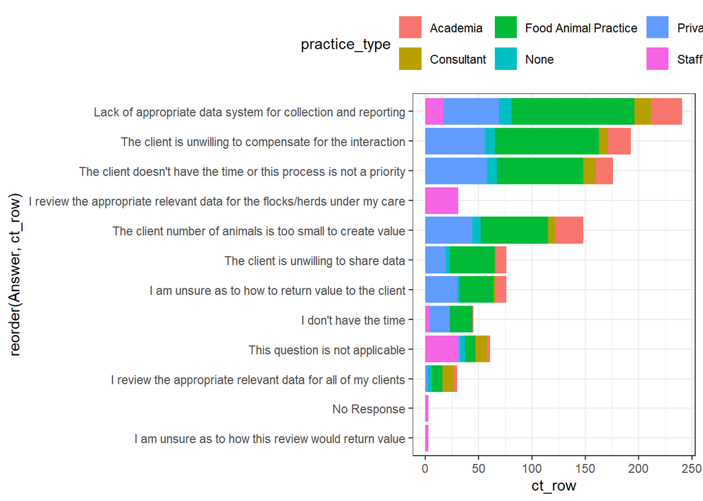

## Question 31

Q31 Would you find value in having a confidential report comparing your antimicrobial use and prescribing practices to an aggregate of antimicrobial use data from other veterinarians in a similar practice situation?

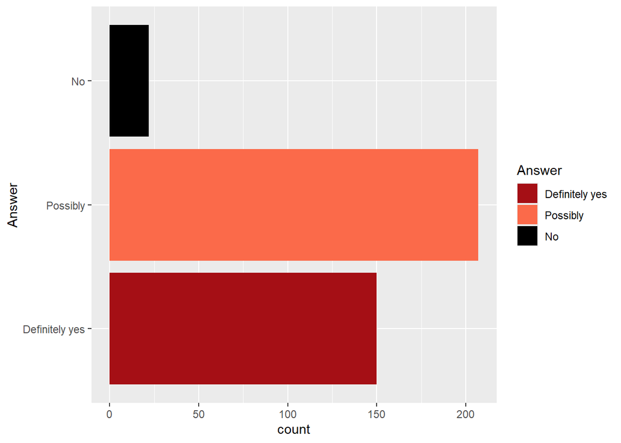

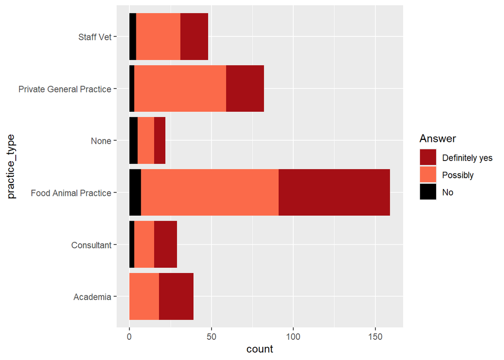

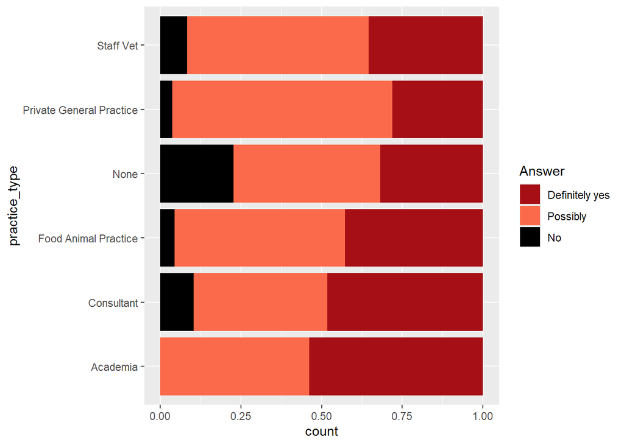

## Q32 Guidance Documents

[figure not shown]

## Question 33

Q33 How many times a year do you find yourself in need of additional information to support an antimicrobial use or prescribing decision for food animals?

## Question 34

Q34 In the last year, which of the following resources have you utilized for information to support an antimicrobial use or prescribing decision?